Final Phase of Project 1

# Topics to be covered:

## - A quick Recall of the previous phases

## -EDA,Data -Preprocessing -Normalization

## - New implemenation:

## -Cross Validations for LDA QDA

```r
library(e1071)
library(caret)
library(magrittr)
library(plyr)
library(dplyr)
```

```r
library(corrplot)
library(randomForest)
library(pROC)
library(Epi)
library(nnet)
library(party)
heart.data <- read.csv("https://archive.ics.uci.edu/ml/machine-learning-databases/heart-disease/processed.cleveland.data",header=FALSE,sep=",",na.strings = '?')
```

```r
names(heart.data) <- c( "Age", "Gender", "ChestPain", "RestBP", "Chol","FBS", "RestECG","MaxHR","ExAng", "OldPeak","Slope", "ca", "thal", "HeartDisease")

#Check the dimension of the data
dim(heart.data)
```

```
## [1] 303  14
```

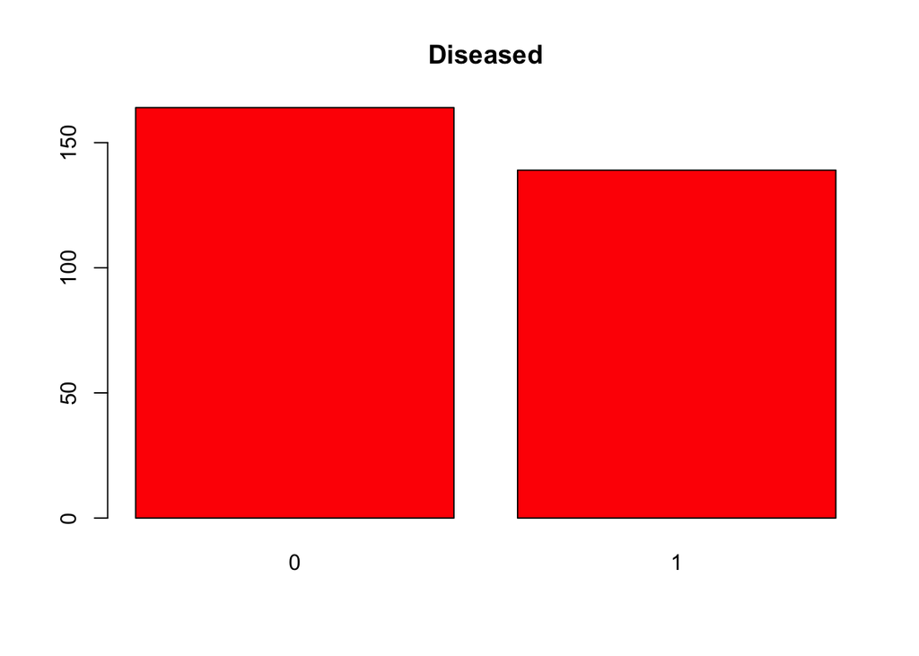

```r
heart.data$HeartDisease[heart.data$HeartDisease > 0] <- 1
barplot(table(heart.data$HeartDisease), main="Diseased", col="Red")
```

```r
heart.data$Age = as.numeric(heart.data$Age)
heart.data$Gender=as.numeric(heart.data$Gender)
heart.data$ChestPain=as.numeric(heart.data$ChestPain)
heart.data$RestBP=as.numeric(heart.data$RestBP)
heart.data$Chol=as.numeric(heart.data$Chol)
heart.data$FBS=as.numeric(heart.data$FBS)
heart.data$RestECG=as.numeric(heart.data$RestECG)
heart.data$MaxHR=as.numeric(heart.data$MaxHR)
heart.data$ExAng=as.numeric(heart.data$ExAng)
heart.data$OldPeak=as.numeric(heart.data$OldPeak)
heart.data$Slope=as.numeric(heart.data$Slope)
heart.data$ca=as.numeric(heart.data$ca)
heart.data$thal=as.numeric(heart.data$thal)
heart.data$HeartDisease=as.factor(heart.data$HeartDisease)

sum(!complete.cases(heart.data))
```

```
## [1] 6
```

```r
#Removing rows with NaN
heart.data <- heart.data[complete.cases(heart.data),]

# categories = cut(heart.data$Age, c(0,20,40,60,Inf))
# heart.data$Agegrp = as.numeric(categories)
# heart.data$Agegrp = factor(heart.data$Agegrp)


#Removing near zero variance variables
library(caret)
library(magrittr)
library(dplyr)
nzv <- nearZeroVar(heart.data)
names(data)[nzv]
```

```r
#Normalisation
preProcValues <- preProcess(heart.data, method = c("range"))
dataNorm <- predict(preProcValues, heart.data)
#Removing highly correlated variables
d.num <- dataNorm %>% select(which(sapply(dataNorm, is.numeric)))
too_high <- findCorrelation(cor(d.num), cutoff = 0.725, verbose = FALSE)
names(d.num)[too_high]
```

```
## character(0)
```

```r
data = dataNorm[,-c(too_high)]


size <- floor(0.05 * nrow (heart.data))
indxSample <- sample(seq_len(nrow(heart.data)), size = size)
sample <- heart.data[indxSample, ]
length(levels(sample$HeartDisease))
```

```
## [1] 2
```

```r
#SBF
filterCtrl <- sbfControl(functions = rfSBF, method = "repeatedcv", verbose = FALSE, repeats = 5)
rfWithFilter <- sbf(form = HeartDisease ~ ., data = sample, sbfControl = filterCtrl, allowParallel = TRUE, variables=TRUE)
rfWithFilter
```

```
##
## Selection By Filter
##
## Outer resampling method: Cross-Validated (10 fold, repeated 5 times)
##
## Resampling performance:
##
##  Accuracy    Kappa AccuracySD KappaSD
##      0.71 -0.04167     0.3364  0.2041
##
## Using the training set, 3 variables were selected:
##    OldPeak, Slope, ca.
##
## During resampling, the top 5 selected variables (out of a possible 5):
##    Slope (90%), ca (80%), OldPeak (74%), thal (26%), MaxHR (2%)
##
## On average, 2.7 variables were selected (min = 1, max = 4)
```

```r
selections <- rfWithFilter$variables$selectedVars
selections <- append(selections, "HeartDisease")
selections
```

```
## [1] "OldPeak"      "Slope"        "ca"           "HeartDisease"
```

```r
selections
```

```
## [1] "OldPeak"      "Slope"        "ca"           "HeartDisease"
```

```r
data<-heart.data
subdata <- data[c("thal","Age","Slope","HeartDisease")]
head(subdata)
```

```
##   thal Age Slope HeartDisease
## 1    6  63     3            0
## 2    3  67     2            1
## 3    7  67     2            1
## 4    3  37     3            0
## 5    3  41     1            0
## 6    3  56     1            0
```

```r
summary(subdata)
```

```
##       thal            Age            Slope       HeartDisease
##  Min.   :3.000   Min.   :29.00   Min.   :1.000   0:160
##  1st Qu.:3.000   1st Qu.:48.00   1st Qu.:1.000   1:137
##  Median :3.000   Median :56.00   Median :2.000
##  Mean   :4.731   Mean   :54.54   Mean   :1.603
##  3rd Qu.:7.000   3rd Qu.:61.00   3rd Qu.:2.000
##  Max.   :7.000   Max.   :77.00   Max.   :3.000
```

```r
sub.num <- subdata %>% select(which(sapply(subdata, is.numeric)))
```

Data splitting

```r
set.seed(1313)
size <- floor(0.75 * nrow(subdata))
indxTrain <- sample(seq_len(nrow(subdata)), size = size)

dataTrain <-subdata[indxTrain, ]
dataTest <- subdata[-indxTrain, ]
```

# Classifiers

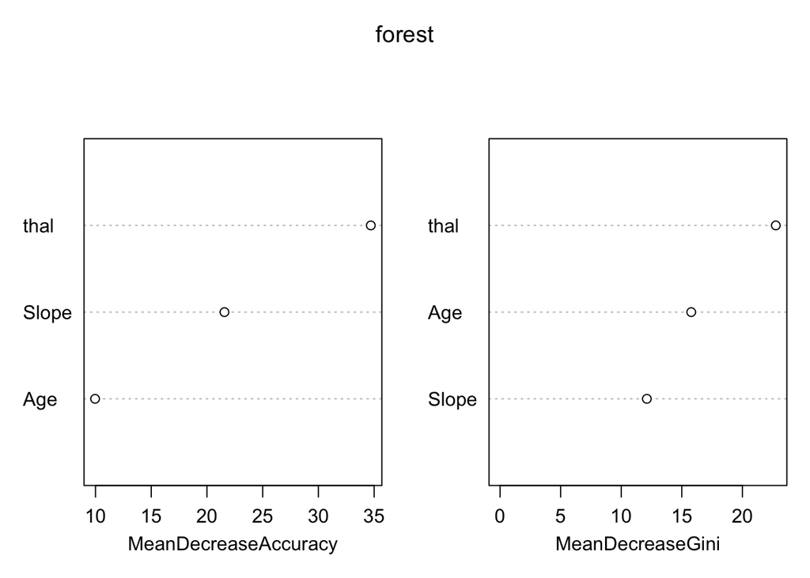

```r
forest <- randomForest(HeartDisease ~ ., data = dataTrain, importance = TRUE, na.action = na.omit)
varImpPlot(forest)
```

```r
importance(forest)
```

```
##               0        1 MeanDecreaseAccuracy MeanDecreaseGini
## thal  30.200853 30.58052            34.703818         22.75921
## Age    4.582326 10.36867             9.960714         15.77689
## Slope 16.958189 18.70075            21.570385         12.11349
```

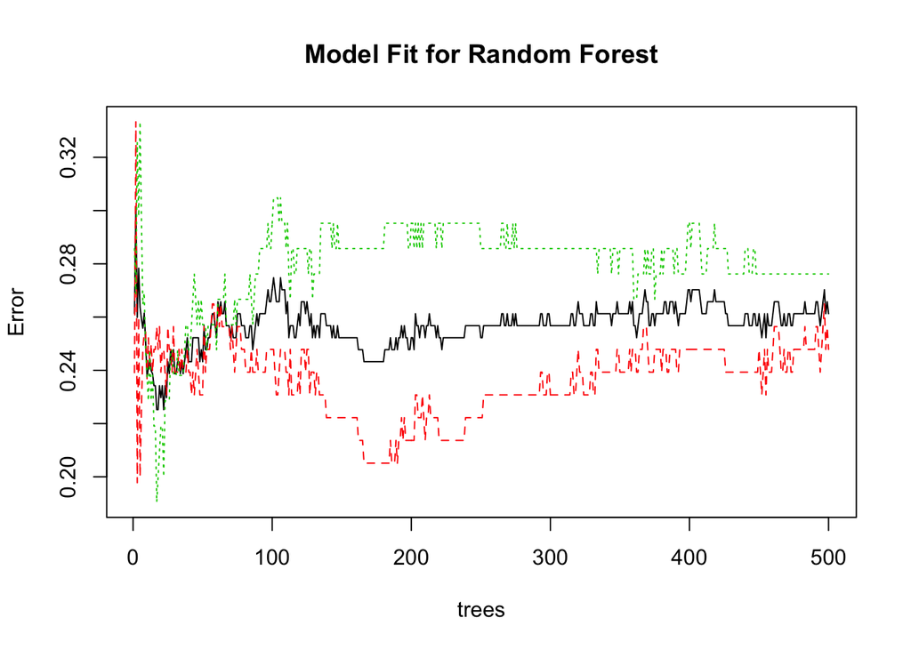

```r
predForest = predict(forest, dataTest, type="class")
plot(forest, main="Model Fit for Random Forest")
```

```r
forestTab <- table(true = dataTest$HeartDisease, predicted = predForest)
rfAcc <- sum(diag(forestTab)) / sum(forestTab)
rfAcc
```

```
## [1] 0.7333333
```

## Tree Tree is undirected graph with nodes and leaf nodes that can indicate the value of Class.

```r
tree<-ctree(HeartDisease ~ ., data=dataTrain)
predTree = predict(tree, dataTest)
treeTab <- table(true = dataTest$HeartDisease, predicted = predTree)
treeAcc <- sum(diag(treeTab)) / sum(treeTab)
treeAcc
```

```
## [1] 0.7466667
```

## Nearest Neighbours This is a non-parametric method which input has k nearest examples from the training set in the space of numerical features.

```r
#Finding optimal k
tuneK <- 1:50
performance <- sapply(tuneK, function(k) {
  knnFit <- knn3(HeartDisease ~ ., data = dataTrain, k=k)
  tab <- table(true = dataTest$HeartDisease,
          predict = predict(knnFit,dataTest, type="class"))
  sum(diag(tab)) / sum(tab)
})

optimal_k = which.max(performance)
optimal_k
```

```
## [1] 9
```

```r
performance[optimal_k]
```

```
## [1] 0.7733333
```

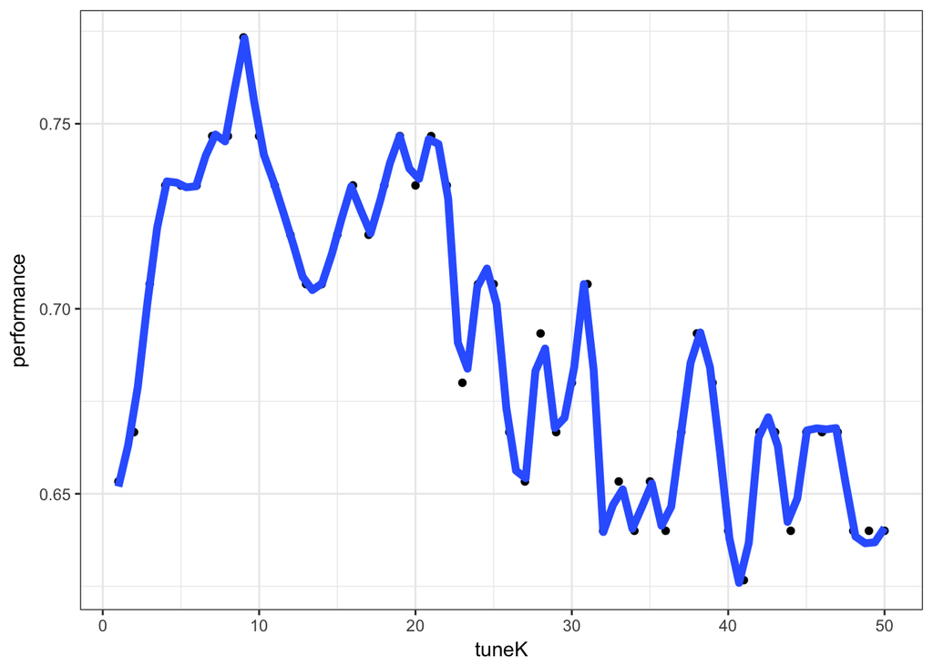

```r
df <- data.frame(tuneK, performance)

ggplot(df, aes(tuneK, performance)) +
  geom_point() +
  geom_smooth(se=FALSE, span=0.1, size=2) +
  theme_bw()
```

```r
###Applying optimal k
knnFit <- knn3(HeartDisease ~ ., data = dataTrain, k=optimal_k)
predKnn <- predict(knnFit, dataTest, type="class")
tab_optimal <- table(true = dataTest$HeartDisease, predicted = predKnn)
knnAcc <- sum(diag(tab_optimal)) / sum(tab_optimal)
knnAcc
```

```
## [1] 0.7733333
```

```r
svm<-svm(HeartDisease ~ ., dataTrain, useCells=TRUE, threads=3)

predSVM = predict(svm, dataTest, type="class")
svmTab <- table(true = dataTest$HeartDisease, predicted = predSVM)
svmAcc <- sum(diag(svmTab)) / sum(svmTab)
svmAcc
```

```
## [1] 0.72
```

## Multinomial Logistic Regression Logistic regression, also referred to as logit model is a predictive analysis.

```r
vglm <- multinom(HeartDisease ~ ., data=dataTrain)
predVglm = predict(vglm, dataTest, type="class")
vglmTab <- table(true = dataTest$HeartDisease, predicted = predVglm)
vglmAcc <- sum(diag(vglmTab)) / sum(vglmTab)
vglmAcc
```

```
## [1] 0.7066667
```

## Naive Bayes Naive Bayes is a classifier that uses prior probability, to make a prediction. It is called ‘naive’, because it simplifies the calculation of probabilities by assuming that each attribute belonging to a given class value is independent.

```r
bayes <- naiveBayes(HeartDisease ~ ., data = dataTrain)
predBayes = predict(bayes, dataTest, type="class")
bayesTab <- table(true = dataTest$HeartDisease, predicted = predBayes)
bayesAcc <- sum(diag(bayesTab)) / sum(bayesTab)
bayesAcc
```

```
## [1] 0.72
```

```r
NN <- naiveBayes(HeartDisease ~ ., data = dataTrain)
predNN = predict(bayes, dataTest, type="class")
NNTab <- table(true = dataTest$HeartDisease, predicted = predNN)
NNAcc <- sum(diag(NNTab)) / sum(NNTab)
NNAcc
```

```
## [1] 0.72
```

Neural Network model

```r
data<-heart.data
k = 10
flds <- createFolds(data$HeartDisease, k, list = TRUE, returnTrain = FALSE)
cv.results <- matrix(rep(0, 3*k), nrow=k)
colnames(cv.results)<-c("fold","TR error", "VA error")
cv.results[,"TR error"]<-0
cv.results[,"VA error"]<-0
for(j in 1:k) {

  data.learn <- data[-flds[[j]],]
  data.test <- data[flds[[j]],]

  nn.model <- nnet(HeartDisease ~.,  data = data.learn, size = 4, maxit = 10000, decay = 0.01)

  nn.model.resL <- predict(nn.model, data.learn[-14], decision.values = FALSE)
  nn.model.resT <- predict(nn.model, data.test[-14], decision.values = FALSE)
  nn.model.resL[nn.model.resL[,1]<0.5]<-0
  nn.model.resL[nn.model.resL[,1]>=0.5]<-1
  nn.model.resT[nn.model.resT[,1]<0.5]<-0
  nn.model.resT[nn.model.resT[,1]>=0.5]<-1
  tableL <- cbind(nn.model.resL, data.learn[,11])
  tableT <- cbind(nn.model.resT, data.test[,11])

  sum <- 0
  for (i in 1:nrow(tableL)) {
    if (tableL[i,1] != tableL[i,2]) sum = sum + 1
  }
  sum/nrow(tableL)
  cv.results[j, "TR error"]<-(sum/nrow(tableL))*100

  sum <- 0
  for (i in 1:nrow(tableT)) {
    if (tableT[i,1] != tableT[i,2]) sum = sum + 1
  }
  sum/nrow(tableT)
  cv.results[j, "VA error"]<-(sum/nrow(tableT))*100

  cv.results[j,"fold"]<-j
}
(TR.error <-1-((mean(cv.results[,"TR error"])))/100)
```

```
## [1] 0.1077534
```

```r
(VA.error <- 1-((mean(cv.results[,"VA error"])))/100)
```

```
## [1] 0.1309195
```

# Performance We will check the performance of used classifiers with confusion matrix, Area Under Curve (AUC) and Macro Averaged Metrics.

## Confusion Matrix Confusion matrix is a table describing performance of classifiers. Besides, confusionMatrix() function also provides additional statistics.

```r
#Random Forest
rfConfusionMatrix <- confusionMatrix(predForest, dataTest$HeartDisease)
rfConfusionMatrix
```

```
## Confusion Matrix and Statistics
##
##           Reference
## Prediction  0  1
##          0 32  9
##          1 11 23
##
##                Accuracy : 0.7333
##                  95% CI : (0.6186, 0.8289)
##     No Information Rate : 0.5733
##     P-Value [Acc > NIR] : 0.003042
##
##                   Kappa : 0.4593
##  Mcnemar's Test P-Value : 0.823063
##
##             Sensitivity : 0.7442
##             Specificity : 0.7188
##          Pos Pred Value : 0.7805
##          Neg Pred Value : 0.6765
##              Prevalence : 0.5733
##          Detection Rate : 0.4267
##    Detection Prevalence : 0.5467
##       Balanced Accuracy : 0.7315
##
##        'Positive' Class : 0
##
```

```r
#Tree
treeConfusionMatrix <- confusionMatrix(predTree, dataTest$HeartDisease)
treeConfusionMatrix
```

```
## Confusion Matrix and Statistics
##
##           Reference
## Prediction  0  1
##          0 28  4
##          1 15 28
##
##                Accuracy : 0.7467
##                  95% CI : (0.633, 0.8401)
##     No Information Rate : 0.5733
##     P-Value [Acc > NIR] : 0.001387
##
##                   Kappa : 0.504
##  Mcnemar's Test P-Value : 0.021781
##
##             Sensitivity : 0.6512
##             Specificity : 0.8750
##          Pos Pred Value : 0.8750
##          Neg Pred Value : 0.6512
##              Prevalence : 0.5733
##          Detection Rate : 0.3733
##    Detection Prevalence : 0.4267
##       Balanced Accuracy : 0.7631
##
##        'Positive' Class : 0
##
```

```r
#Nearest Neighbours
knnConfusionMatrix <- confusionMatrix(predKnn, dataTest$HeartDisease)
knnConfusionMatrix
```

```
## Confusion Matrix and Statistics
##
##           Reference
## Prediction  0  1
##          0 32  6
##          1 11 26
##
##                Accuracy : 0.7733
##                  95% CI : (0.6621, 0.8621)
##     No Information Rate : 0.5733
##     P-Value [Acc > NIR] : 0.0002361
##
##                   Kappa : 0.5458
##  Mcnemar's Test P-Value : 0.3319755
##
##             Sensitivity : 0.7442
##             Specificity : 0.8125
##          Pos Pred Value : 0.8421
##          Neg Pred Value : 0.7027
##              Prevalence : 0.5733
##          Detection Rate : 0.4267
##    Detection Prevalence : 0.5067
##       Balanced Accuracy : 0.7783
##
##        'Positive' Class : 0
##
```

```r
#SVM
svmConfusionMatrix <- confusionMatrix(predSVM, dataTest$HeartDisease)
svmConfusionMatrix
```

```
## Confusion Matrix and Statistics
##
##           Reference
## Prediction  0  1
##          0 29  7
##          1 14 25
##
##                Accuracy : 0.72
##                  95% CI : (0.6044, 0.8176)
##     No Information Rate : 0.5733
##     P-Value [Acc > NIR] : 0.006269
##
##                   Kappa : 0.4433
##  Mcnemar's Test P-Value : 0.190430
##
##             Sensitivity : 0.6744
##             Specificity : 0.7812
##          Pos Pred Value : 0.8056
##          Neg Pred Value : 0.6410
##              Prevalence : 0.5733
##          Detection Rate : 0.3867
##    Detection Prevalence : 0.4800
##       Balanced Accuracy : 0.7278
##
##        'Positive' Class : 0
##
```

```r
#Multinomial Logistic Regression
mlrConfusionMatrix <- confusionMatrix(predVglm, dataTest$HeartDisease)
mlrConfusionMatrix
```

```
## Confusion Matrix and Statistics
##
##           Reference
## Prediction  0  1
##          0 30  9
##          1 13 23
##
##                Accuracy : 0.7067
##                  95% CI : (0.5902, 0.8062)
##     No Information Rate : 0.5733
##     P-Value [Acc > NIR] : 0.01216
##
##                   Kappa : 0.4099
##  Mcnemar's Test P-Value : 0.52243
##
##             Sensitivity : 0.6977
##             Specificity : 0.7188
##          Pos Pred Value : 0.7692
##          Neg Pred Value : 0.6389
##              Prevalence : 0.5733
##          Detection Rate : 0.4000
##    Detection Prevalence : 0.5200
##       Balanced Accuracy : 0.7082
##
##        'Positive' Class : 0
##
```

```r
#Naive Bayes
bayesConfusionMatrix <- confusionMatrix(predBayes, dataTest$HeartDisease)
bayesConfusionMatrix
```

```
## Confusion Matrix and Statistics
##
##           Reference
## Prediction  0  1
##          0 31  9
##          1 12 23
##
##                Accuracy : 0.72
##                  95% CI : (0.6044, 0.8176)
##     No Information Rate : 0.5733
##     P-Value [Acc > NIR] : 0.006269
##
##                   Kappa : 0.4345
##  Mcnemar's Test P-Value : 0.662521
##
##             Sensitivity : 0.7209
##             Specificity : 0.7188
##          Pos Pred Value : 0.7750
##          Neg Pred Value : 0.6571
##              Prevalence : 0.5733
##          Detection Rate : 0.4133
##    Detection Prevalence : 0.5333
##       Balanced Accuracy : 0.7198
##
##        'Positive' Class : 0
##
```

```r
#Neural Networks

NNConfusionMatrix <- confusionMatrix(predNN, dataTest$HeartDisease)
NNConfusionMatrix
```

```
## Confusion Matrix and Statistics
##
##           Reference
## Prediction  0  1
##          0 31  9
##          1 12 23
##
##                Accuracy : 0.72
##                  95% CI : (0.6044, 0.8176)
##     No Information Rate : 0.5733
##     P-Value [Acc > NIR] : 0.006269
##
##                   Kappa : 0.4345
##  Mcnemar's Test P-Value : 0.662521
##
##             Sensitivity : 0.7209
##             Specificity : 0.7188
##          Pos Pred Value : 0.7750
##          Neg Pred Value : 0.6571
##              Prevalence : 0.5733
##          Detection Rate : 0.4133
##    Detection Prevalence : 0.5333
##       Balanced Accuracy : 0.7198
##
##        'Positive' Class : 0
##
```

## Area Under Curve Receiver Operating Characteristics curve (ROC) visualises the performance of a classifier. AUC is the Area Under the ROC Curve, where the value equal to 1 means a perfect test.

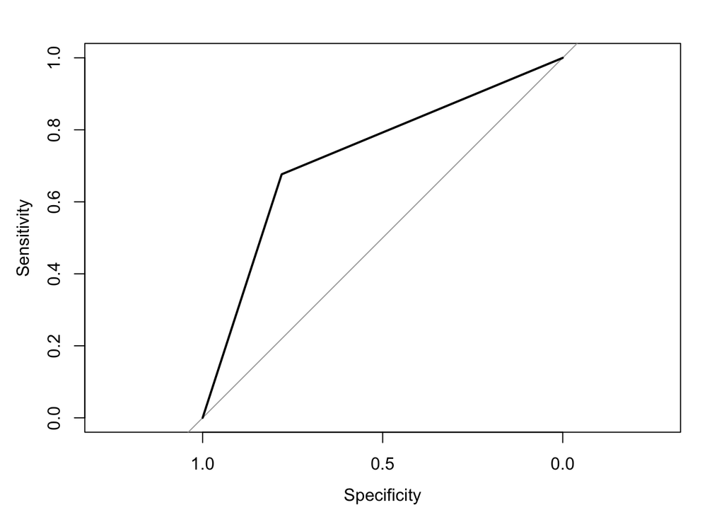

```r
#Random Forest
rfAUC <- auc(predForest, as.numeric(dataTest$HeartDisease))
rfrocobj <- plot.roc(predForest, as.numeric(dataTest$HeartDisease))
```

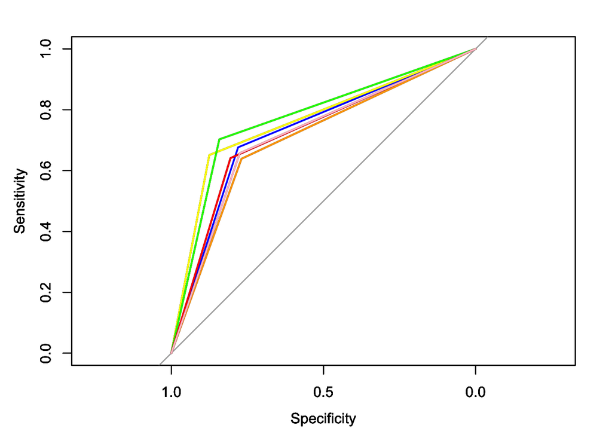

```r
plot(rfrocobj, col="blue")
par(new = TRUE)


#Tree
treeAUC <- auc(predTree, as.numeric(dataTest$HeartDisease))
treerocobj <- plot.roc(predTree, as.numeric(dataTest$HeartDisease))
plot(treerocobj, col="yellow", add=TRUE)
par(new = TRUE)

#Nearest Neighbours
knnAUC <- auc(predForest, as.numeric(dataTest$HeartDisease))
knnrocobj <- plot.roc(predKnn, as.numeric(dataTest$HeartDisease))
plot(knnrocobj, col="green", add=TRUE)
par(new = TRUE)

#SVM
svmAUC <- auc(predSVM, as.numeric(dataTest$HeartDisease))
svmrocobj <- plot.roc(predSVM, as.numeric(dataTest$HeartDisease))
plot(svmrocobj, col="red", add=TRUE)
par(new = TRUE)

#Multinomial Logistic Regression
vglmAUC <- auc(predVglm, as.numeric(dataTest$HeartDisease))
vglmrocobj <- plot.roc(predVglm, as.numeric(dataTest$HeartDisease))
plot(vglmrocobj, col="orange", add=TRUE)
par(new = TRUE)


#Naive Bayes
bayesAUC <- auc(predBayes, as.numeric(dataTest$HeartDisease))
bayesrocobj <- plot.roc(predBayes, as.numeric(dataTest$HeartDisease))
plot(bayesrocobj, col="pink", add=TRUE)
```

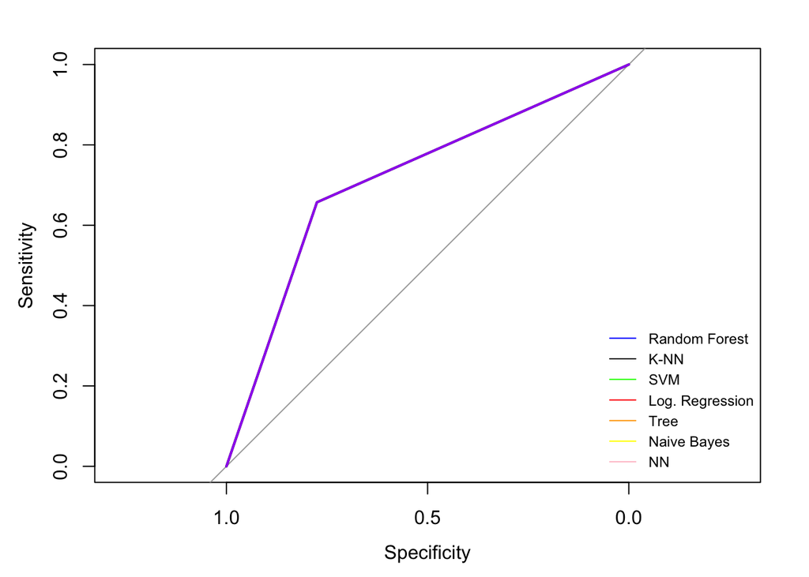

```r
#Neural Networks
NNAUC <- auc(predNN, as.numeric(dataTest$HeartDisease))
NNrocobj <- plot.roc(predNN, as.numeric(dataTest$HeartDisease))
plot(NNrocobj, col="purple", add=TRUE)

legend('bottomright', c('Random Forest','K-NN', 'SVM', 'Log. Regression', 'Tree', 'Naive Bayes','NN'), lty=1, col=c('blue', 'black', 'green', 'red',' orange', 'yellow', 'pink','purple'), bty='n', cex=.75)
```

##Macro-Averaged Metrics Tables for In Macro-averaged Metrics give an average of the following:

Precision = TP / (TP+FP), fraction of correct predictions for a certain class.

Recall = TP / (TP+FN), instances of a class that were correctly predicted.

Precision shows how consistent are those evaluations - how many values were correctly estimated.

F1 is a harmonic mean of precision and recall. That is why has a very similar values like Precision and Recall and shows that those values are not various from each other.

```r
#RandomForest

forestPrec<-(diag(forestTab))/(colSums(forestTab))
forestRecall<-(diag(forestTab))/(rowSums(forestTab))
forestF1<-2*forestPrec*forestRecall/(forestPrec+forestRecall)

data.frame(forestPrec, forestRecall, forestF1)
```

```
##   forestPrec forestRecall  forestF1
## 0  0.7804878     0.744186 0.7619048
## 1  0.6764706     0.718750 0.6969697
```

```r
mForestPrec = mean(forestPrec)
mForestRecall = mean(forestRecall)
mForestF1 = mean(forestF1)
mamForest<-data.frame(mForestPrec, mForestRecall, mForestF1)
mamForest
```

```
##   mForestPrec mForestRecall mForestF1
## 1   0.7284792      0.731468 0.7294372
```

```r
#Tree

treePrec<-(diag(treeTab))/(colSums(treeTab))
treeRecall<-(diag(treeTab))/(rowSums(treeTab))
treeF1<-2*treePrec*treeRecall/(treePrec+treeRecall)

data.frame(treePrec, treeRecall, treeF1)
```

```
##    treePrec treeRecall    treeF1
## 0 0.8750000  0.6511628 0.7466667
## 1 0.6511628  0.8750000 0.7466667
```

```r
mTreePrec = mean(treePrec)
mTreeRecall = mean(treeRecall)
mTreeF1 = mean(treeF1)
mamTree<-data.frame(mTreePrec, mTreeRecall, mTreeF1)
mamTree
```

```
##   mTreePrec mTreeRecall   mTreeF1
## 1 0.7630814   0.7630814 0.7466667
```

```r
#Nearest Neighbours

knnPrec<-(diag(tab_optimal))/(colSums(tab_optimal))
knnRecall<-(diag(tab_optimal))/(rowSums(tab_optimal))
knnF1<-2*knnPrec*knnRecall/(knnPrec+knnRecall)

data.frame(knnPrec, knnRecall, knnF1)
```

```
##     knnPrec knnRecall     knnF1
## 0 0.8421053  0.744186 0.7901235
## 1 0.7027027  0.812500 0.7536232
```

```r
mKnnPrec = mean(knnPrec)
mKnnRecall = mean(knnRecall)
mKnnF1 = mean(knnF1)
mamKnn<-data.frame(mKnnPrec, mKnnRecall, mKnnF1)
mamKnn
```

```
##   mKnnPrec mKnnRecall    mKnnF1
## 1 0.772404   0.778343 0.7718733
```

```r
#SVM

svmPrec<-(diag(svmTab))/(colSums(svmTab))
svmRecall<-(diag(svmTab))/(rowSums(svmTab))
svmF1<-2*svmPrec*svmRecall/(svmPrec+svmRecall)

data.frame(svmPrec, svmRecall, svmF1)
```

```
##     svmPrec svmRecall     svmF1
## 0 0.8055556 0.6744186 0.7341772
## 1 0.6410256 0.7812500 0.7042254
```

```r
mSvmPrec = mean(svmPrec)
mSvmRecall = mean(svmRecall)
mSvmF1 = mean(svmF1)
mamSvm<-data.frame(mSvmPrec, mSvmRecall, mSvmF1)
mamSvm
```

```
##    mSvmPrec mSvmRecall    mSvmF1
## 1 0.7232906  0.7278343 0.7192013
```

```r
#Multinomial Logistic Regression

vglmPrec<-(diag(vglmTab))/(colSums(vglmTab))
vglmRecall<-(diag(vglmTab))/(rowSums(vglmTab))
vglmF1<-2*vglmPrec*vglmRecall/(vglmPrec+vglmRecall)

data.frame(vglmPrec, vglmRecall, vglmF1)
```

```
##    vglmPrec vglmRecall    vglmF1
## 0 0.7692308  0.6976744 0.7317073
## 1 0.6388889  0.7187500 0.6764706
```

```r
mVglmPrec = mean(vglmPrec)
mVglmRecall = mean(vglmRecall)
mVglmF1 = mean(vglmF1)
mamVglm<-data.frame(mVglmPrec, mVglmRecall, mVglmF1)
mamVglm
```

```
##   mVglmPrec mVglmRecall  mVglmF1
## 1 0.7040598   0.7082122 0.704089
```

```r
#Bayes

bayesPrec<-(diag(bayesTab))/(colSums(bayesTab))
bayesRecall<-(diag(bayesTab))/(rowSums(bayesTab))
bayesF1<-2*bayesPrec*bayesRecall/(bayesPrec+bayesRecall)

data.frame(bayesPrec, bayesRecall, bayesF1)
```

```
##   bayesPrec bayesRecall   bayesF1
## 0 0.7750000   0.7209302 0.7469880
## 1 0.6571429   0.7187500 0.6865672
```

```r
mBayesPrec = mean(bayesPrec)
mBayesRecall = mean(bayesRecall)
mBayesF1 = mean(bayesF1)
mamBayes<-data.frame(mBayesPrec, mBayesRecall, mBayesF1)
mamBayes
```

```
##   mBayesPrec mBayesRecall  mBayesF1
## 1  0.7160714    0.7198401 0.7167776
```

```r
#Neural Networks
NNPrec<-(diag(NNTab))/(colSums(NNTab))
NNRecall<-(diag(NNTab))/(rowSums(NNTab))
NNF1<-2*NNPrec*NNRecall/(NNPrec+NNRecall)

data.frame(NNPrec, NNRecall, NNF1)
```

```
##      NNPrec  NNRecall      NNF1
## 0 0.7750000 0.7209302 0.7469880
## 1 0.6571429 0.7187500 0.6865672
```

```r
NNPrec = mean(NNPrec)
NNRecall = mean(NNRecall)
NNF1 = mean(NNF1)
NN<-data.frame(NNPrec, NNRecall, NNF1)
NN
```

```
##      NNPrec  NNRecall      NNF1
## 1 0.7160714 0.7198401 0.7167776
```

```r
#Conclusions

sum_table <- matrix(c(rfAcc, rfAUC, mForestPrec, mForestRecall, mForestF1,   treeAcc, treeAUC, mTreePrec, mTreeRecall, mTreeF1, knnAcc, knnAUC, mKnnPrec, mKnnRecall, mKnnF1, svmAcc, svmAUC, mSvmPrec, mSvmRecall, mSvmF1, vglmAcc, vglmAUC,mVglmPrec, mVglmRecall, mVglmF1,  bayesAcc, bayesAUC, mBayesPrec, mBayesRecall, mBayesF1,NNAcc, bayesAUC, NNPrec, NNRecall, NNF1), ncol=5, nrow = 7 , byrow = TRUE)
colnames(sum_table) <- c("Accuracy", "AUC","Precision","Recall","F1")
rownames(sum_table) <- c("Bayes","RF", "TREE", "KNN", "SVM", "MLR","NN")
sum_table
```

[output not shown]

```r
library(MASS)
library(FactoMineR)
require(rJava)
```

[output not shown]

```r
require(FSelector)
```

[output not shown]

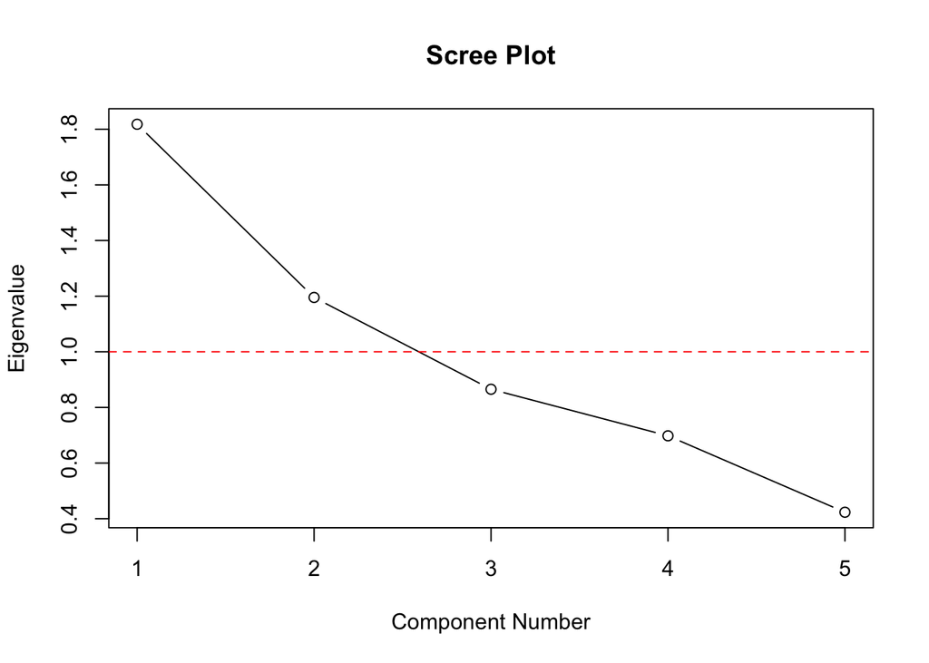

```r
library(klaR)
library(ipred)
library(e1071)
library(class)
library(readxl)
library(caret)
library(lfda)
N <- nrow(data)
learn <- sample(1:N, round(2*N/3))
nlearn <- length(learn)
ntest <- N - nlearn
data.learn <- data[learn, ]
data.test <- data[-learn, ]

# Set numerical and categorical columns
data.colsNum <- c(1, 4, 5, 8, 10)
data.colsCat <- c(2, 3, 6, 7, 9, 11)

# PCA: Checking the possible correlation between the numeric variables in the training set (informative)
data.onlynum <- data.learn[,c("Age","RestBP", "Chol", "MaxHR", "Slope")]
Scree.Plot <- function(R,main="Scree Plot",sub=NULL){
  roots <- eigen(R)$values
  x <- 1:dim(R)[1]
  plot(x, roots, type="b", col='black', ylab="Eigenvalue",
       xlab="Component Number", main=main, sub=sub)
  abline(h=1,lty=2,col="red")
}
pca_cor <- cor(data.onlynum[,1:length(data.colsNum)])
Scree.Plot(pca_cor, main ="Scree Plot")
```

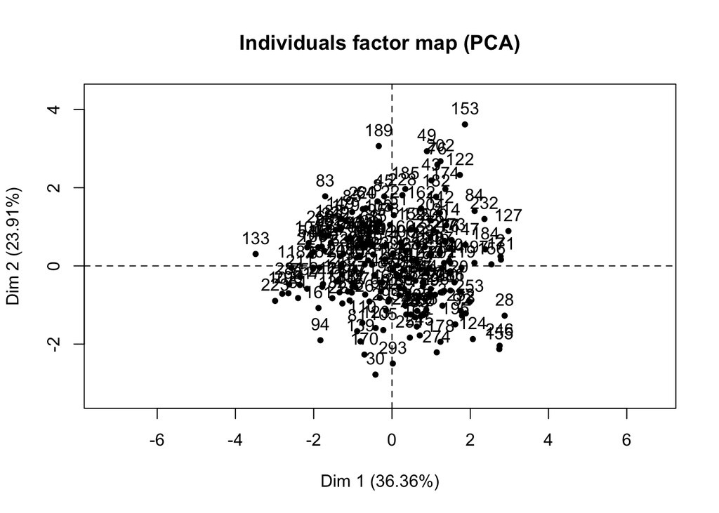

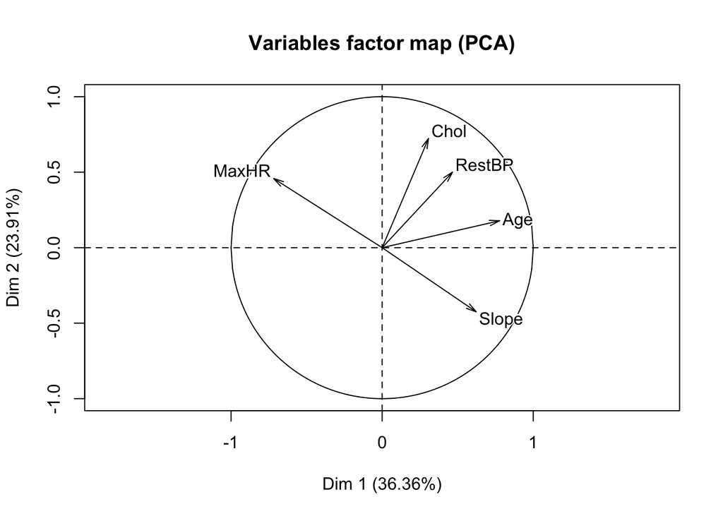

```r
pca = PCA(data.onlynum)
```

```r
summary(pca)
```

```
##
## Call:
## PCA(X = data.onlynum)
##
##
## Eigenvalues
##                        Dim.1   Dim.2   Dim.3   Dim.4   Dim.5
## Variance               1.818   1.195   0.865   0.698   0.423
## % of var.             36.360  23.907  17.307  13.960   8.465
## Cumulative % of var.  36.360  60.268  77.575  91.535 100.000
##
## Individuals (the 10 first)
##            Dist    Dim.1    ctr   cos2    Dim.2    ctr   cos2    Dim.3
## 2      |  2.960 |  2.774  2.138  0.878 |  0.243  0.025  0.007 |  0.088
## 142    |  2.301 |  1.224  0.416  0.283 |  1.358  0.779  0.348 |  1.380
## 197    |  2.435 |  2.108  1.234  0.749 |  0.077  0.003  0.001 |  0.788
## 253    |  2.457 |  1.989  1.099  0.655 | -0.920  0.358  0.140 | -0.916
## 179    |  2.031 | -1.178  0.386  0.337 |  1.148  0.557  0.319 | -0.457
## 66     |  1.319 |  1.225  0.417  0.862 |  0.371  0.058  0.079 |  0.203
## 15     |  2.605 | -0.367  0.037  0.020 |  0.871  0.320  0.112 |  1.886
## 289    |  1.280 | -0.816  0.185  0.407 |  0.224  0.021  0.030 | -0.008
## 220    |  1.864 | -0.744  0.154  0.159 |  1.455  0.895  0.609 |  0.070
## 22     |  1.629 | -0.044  0.001  0.001 |  1.488  0.935  0.834 |  0.181
##           ctr   cos2
## 2       0.005  0.001 |
## 142     1.111  0.360 |
## 197     0.362  0.105 |
## 253     0.490  0.139 |
## 179     0.122  0.051 |
## 66      0.024  0.024 |
## 15      2.076  0.524 |
## 289     0.000  0.000 |
## 220     0.003  0.001 |
## 22      0.019  0.012 |
##
## Variables
##           Dim.1    ctr   cos2    Dim.2    ctr   cos2    Dim.3    ctr
## Age    |  0.777 33.223  0.604 |  0.178  2.662  0.032 | -0.235  6.371
## RestBP |  0.466 11.931  0.217 |  0.500 20.936  0.250 |  0.684 54.005
## Chol   |  0.307  5.169  0.094 |  0.723 43.757  0.523 | -0.412 19.593
## MaxHR  | -0.718 28.357  0.516 |  0.458 17.553  0.210 |  0.280  9.083
## Slope  |  0.623 21.320  0.388 | -0.425 15.092  0.180 |  0.308 10.948
##          cos2
## Age     0.055 |
## RestBP  0.467 |
## Chol    0.170 |
## MaxHR   0.079 |
## Slope   0.095 |
```

```r
# CROSS-VALIDATED LDA
kFolds = 10
flds <- createFolds(data$HeartDisease, kFolds, list = TRUE, returnTrain = FALSE)
errors <- matrix(rep(0, 3*kFolds), nrow=kFolds)
colnames(errors)<-c("fold","TR error", "VA error")
errors[,"TR error"]<-0
errors[,"VA error"]<-0
for(i in 1:kFolds) {
  train <- data[-flds[[i]],]
  validation <- data[flds[[i]],]
  lda.model <- lda(HeartDisease ~ ., data=train)
  lda.train.predictions <- predict(lda.model, train)
  lda.validation.predictions <- predict(lda.model, validation)
  tab_t <- table(Truth=data$HeartDisease[-flds[[i]]], Pred=lda.train.predictions$class)
  tab_v <- table(Truth=data$HeartDisease[flds[[i]]], Pred=lda.validation.predictions$class)
  errors[i, "TR error"] <- 1 - sum(tab_t[row(tab_t)==col(tab_t)])/sum(tab_t)
  errors[i, "VA error"] <- 1 - sum(tab_v[row(tab_v)==col(tab_v)])/sum(tab_v)
}
errors
```

```
##       fold  TR error   VA error
##  [1,]    0 0.1460674 0.16666667
##  [2,]    0 0.1460674 0.20000000
##  [3,]    0 0.1647940 0.03333333
##  [4,]    0 0.1385768 0.23333333
##  [5,]    0 0.1460674 0.16666667
##  [6,]    0 0.1498127 0.13333333
##  [7,]    0 0.1455224 0.17241379
##  [8,]    0 0.1498127 0.20000000
##  [9,]    0 0.1492537 0.17241379
## [10,]    0 0.1417910 0.24137931
```

```r
("LDA RESULTS")
```

```
## [1] "LDA RESULTS"
```

```r
(TR.error <- mean(errors[,"TR error"]))
```

```
## [1] 0.1477766
```

```r
(VA.error <- mean(errors[,"VA error"]))
```

```
## [1] 0.171954
```

```r
# CROSS-VALIDATED QDA
kFolds = 10
flds <- createFolds(data$HeartDisease, kFolds, list = TRUE, returnTrain = FALSE)
errors <- matrix(rep(0, 3*kFolds), nrow=kFolds)
colnames(errors)<-c("fold","TR error", "VA error")
errors[,"TR error"]<-0
errors[,"VA error"]<-0
for(i in 1:kFolds) {
  train <- data[-flds[[i]],]
  validation <- data[flds[[i]],]
  qda.model <- qda(HeartDisease ~ ., data=train)
  qda.train.predictions <- predict(qda.model, train)
  qda.validation.predictions <- predict(qda.model, validation)
  tab_t <- table(Truth=data$HeartDisease[-flds[[i]]], Pred=qda.train.predictions$class)
  tab_v <- table(Truth=data$HeartDisease[flds[[i]]], Pred=qda.validation.predictions$class)
  errors[i, "TR error"] <- 1 - sum(tab_t[row(tab_t)==col(tab_t)])/sum(tab_t)
  errors[i, "VA error"] <- 1 - sum(tab_v[row(tab_v)==col(tab_v)])/sum(tab_v)
}
errors
```

```
##       fold  TR error   VA error
##  [1,]    0 0.1273408 0.16666667
##  [2,]    0 0.1273408 0.23333333
##  [3,]    0 0.1385768 0.10000000
##  [4,]    0 0.1423221 0.20000000
##  [5,]    0 0.1460674 0.03333333
##  [6,]    0 0.1268657 0.17241379
##  [7,]    0 0.1086142 0.23333333
##  [8,]    0 0.1380597 0.17241379
##  [9,]    0 0.1385768 0.13333333
## [10,]    0 0.1492537 0.20689655
```

```r
("QDA RESULTS")
```

```
## [1] "QDA RESULTS"
```

```r
(TR.error <- mean(errors[,"TR error"]))
```

```
## [1] 0.1343018
```

```r
(VA.error <- mean(errors[,"VA error"]))
```

```
## [1] 0.1651724
```